**Chapter 2: Gaining reliable knowledge: how do we know what we know?**

## Overwiew

Gaining reliable knowledge in applied wildlife population ecology requires a rigourous and formal process coupling ideas (hypotheses) to reliable measured facts. In the spirit of “embracing the uncertainty”, in this exercise, we focus on three approaches for inference: maximum likelihood estimation, null hypothesis significant testing, and Bayesian estimation.

## Data

Suppose we are tasked with monitoring griffon eggs (also spelled griffin or gryphon). We want to collect evidence on griffons breeding success. We visit 30 nests, and expect to find 20 nests with eggs. The data would look like the plot below.

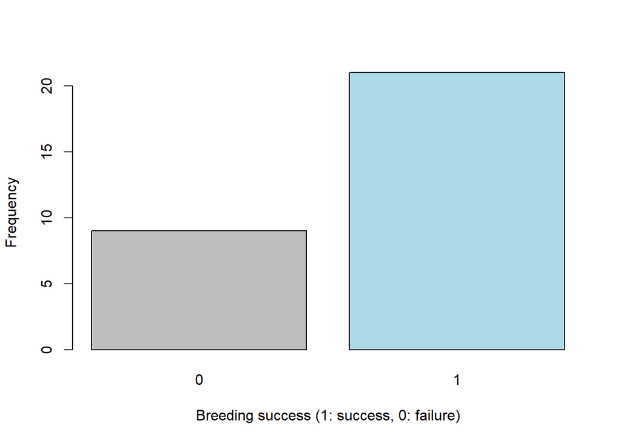

```r
options(scipen = 999)

trials  <- 30
success <- 20
griffon <- sample(c(0, 1),
                  trials,
                  replace = TRUE,
                  prob    = c((trials - success) / trials, success / trials))
barplot(table(griffon),
        col = ifelse(names(table(griffon)) == 0, "grey", "lightblue"),
        ylab = "Frequency",
        xlab = "Breeding success (1: success, 0: failure)")
```

From such data we can calculate the observed proportion of nests with and without eggs.

```r
proportion <- round(sum(griffon) / length(griffon), 2)
1 - proportion
```

[output not shown]

But this does not tell us much. To make generalisable statements about the breeding success, we need to complete some statistical analyses. We examine this data with a simple model that makes the following assumption: at every visit to a griffon nest, we have a probability of p to find eggs.

First, we can use the dbinom() function to find the likelihood for different probabilities of a success. Then, we can find the probability with the maximum likelihood estimate.

```r
n_success  <- sum(griffon)
n_trial    <- length(griffon)
probs      <- seq(0, 1, 0.001)
likelihood <- dbinom(x = n_success, size = n_trial, prob = probs)
mle        <- probs[which.max(likelihood)]
```

Let’s plot the likelihoods and show the probability with the maximum likelihood.

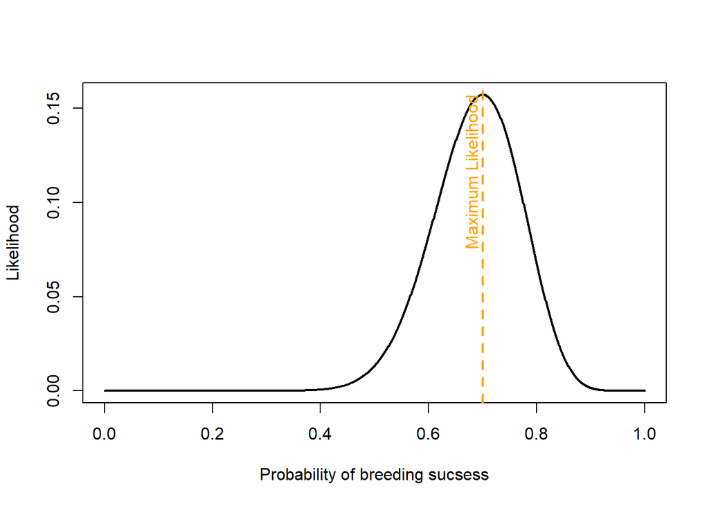

```r
plot(probs,
     likelihood,
     type = "l",
     lwd = 2,
     xlab = "Probability of breeding sucsess",
     ylab = "Likelihood")

abline(v = mle, col = "orange", lwd = 2, lty = 2)
text(mle,
     max(likelihood),
     "Maximum Likelihood",
     pos = 2,
     srt = 90,
     col = "orange")
```

We now have a maximum likelihood estimate for the probability of griffon breeding success. Although the maximum likelihood is the best estimate, this estimate is not enough to draw statistical conclusions. We need to calculate the uncertainty or confidence in our estimates. The 95% confidence intervals mean if we repeat the analysis many times and each time create a confidence interval, 95% of the confidence intervals would contain the true value. We can calculate the confidence intervals for the maximum likelihood estimate, by assuming the statistic follows a normal distribution.

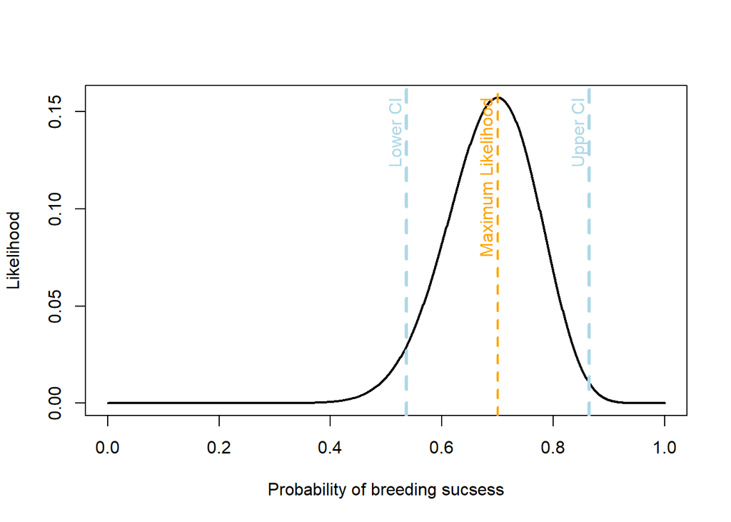

```r
phat <- n_success / n_trial
se   <- sqrt(phat * (1-phat) / n_trial) # standard error

# calculate the lower and upper confidence intervals
lci <- mle - 1.96 * se
uci <- mle + 1.96 * se

plot(probs,
     likelihood,
     type = "l",
     lwd = 2,
     xlab = "Probability of breeding sucsess",
     ylab = "Likelihood")


abline(v = c(lci, uci), col = "lightblue", lwd = 3, lty = 2) # CI lines
abline(v = mle, col = "orange", lwd = 2, lty = 2)

text(mle,
     max(likelihood),
     "Maximum Likelihood",
     pos = 2,
     srt = 90,
     col = "orange")

text(lci,
     max(likelihood),
     "Lower CI",
     pos = 2,
     srt = 90,
     col = "lightblue")

text(uci,
     max(likelihood),
     "Upper CI",
     pos = 2,
     srt = 90,
     col = "lightblue")
```